# Assignment 3: Quantitive Analysis

### 4.5 Age of Person & Race and Ethnicity

**Type of Test**: A continuous variable and a Categorical Variable –> ANOVA Test –> Will give us significance of relationship.

```r
anova_race_ethnicity_AGEP <- aov(AGEP ~race_ethnicity , data = assignment3_vars)
summary(anova_race_ethnicity_AGEP)
```

```
##                   Df  Sum Sq Mean Sq F value Pr(>F)
## race_ethnicity    10  507046   50705   94.36 <2e-16 ***
## Residuals      15032 8077579     537
## ---
## Signif. codes:  0 '***' 0.001 '**' 0.01 '*' 0.05 '.' 0.1 ' ' 1
```

```r
# Calculate Tukey's Honestly Signigicant Difference Test
differences_race_ethnicity_AGEP <- TukeyHSD(anova_race_ethnicity_AGEP)
as_tibble(cbind(pair=row.names(differences_race_ethnicity_AGEP$race_ethnicity),differences_race_ethnicity_AGEP$AGEP))
```

```
## # A tibble: 55 x 1
##    pair
##    <chr>
##  1 Asian Hispanic-Asian (NH)
##  2 Black/African American (Hispanic)-Asian (NH)
##  3 Black/African American (NH)-Asian (NH)
##  4 Native American (Hispanic)-Asian (NH)
##  5 Native American (NH)-Asian (NH)
##  6 Other-Asian (NH)
##  7 Other Race or multiracial (Hispanic)-Asian (NH)
##  8 Other Race or Multiracial (NH)-Asian (NH)
##  9 White (Hispanic)-Asian (NH)
## 10 White (NH)-Asian (NH)
## # ... with 45 more rows
```

```r
differences_race_ethnicity_AGEP
```

```
##   Tukey multiple comparisons of means
##     95% family-wise confidence level
##
## Fit: aov(formula = AGEP ~ race_ethnicity, data = assignment3_vars)
##
## $race_ethnicity
##                                                                                diff
## Asian Hispanic-Asian (NH)                                                7.23066104
## Black/African American (Hispanic)-Asian (NH)                           -10.89853793
## Black/African American (NH)-Asian (NH)                                   2.12636335
## Native American (Hispanic)-Asian (NH)                                   -3.65243075
## Native American (NH)-Asian (NH)                                         -3.67127648
## Other-Asian (NH)                                                       -11.06298975
## Other Race or multiracial (Hispanic)-Asian (NH)                         -3.13279495
## Other Race or Multiracial (NH)-Asian (NH)                               -9.06141412
## White (Hispanic)-Asian (NH)                                             -3.37517933
## White (NH)-Asian (NH)                                                    8.04877345
## Black/African American (Hispanic)-Asian Hispanic                       -18.12919897
## Black/African American (NH)-Asian Hispanic                              -5.10429769
## Native American (Hispanic)-Asian Hispanic                              -10.88309179
## Native American (NH)-Asian Hispanic                                    -10.90193752
## Other-Asian Hispanic                                                   -18.29365079
## Other Race or multiracial (Hispanic)-Asian Hispanic                    -10.36345599
## Other Race or Multiracial (NH)-Asian Hispanic                          -16.29207516
## White (Hispanic)-Asian Hispanic                                        -10.60584037
## White (NH)-Asian Hispanic                                                0.81811241
## Black/African American (NH)-Black/African American (Hispanic)           13.02490127
## Native American (Hispanic)-Black/African American (Hispanic)             7.24610718
## Native American (NH)-Black/African American (Hispanic)                   7.22726144
## Other-Black/African American (Hispanic)                                 -0.16445183
## Other Race or multiracial (Hispanic)-Black/African American (Hispanic)   7.76574298
## Other Race or Multiracial (NH)-Black/African American (Hispanic)         1.83712380
## White (Hispanic)-Black/African American (Hispanic)                       7.52335859
## White (NH)-Black/African American (Hispanic)                            18.94731137
## Native American (Hispanic)-Black/African American (NH)                  -5.77879409
## Native American (NH)-Black/African American (NH)                        -5.79763983
## Other-Black/African American (NH)                                      -13.18935310
## Other Race or multiracial (Hispanic)-Black/African American (NH)        -5.25915829
## Other Race or Multiracial (NH)-Black/African American (NH)             -11.18777747
## White (Hispanic)-Black/African American (NH)                            -5.50154268
```

[output cut: 175 more lines]

```
## Other-Native American (NH)                                             0.9841330
## Other Race or multiracial (Hispanic)-Native American (NH)              0.9999744
## Other Race or Multiracial (NH)-Native American (NH)                    0.0245770
## White (Hispanic)-Native American (NH)                                  0.9999993
## White (NH)-Native American (NH)                                        0.0000000
## Other Race or multiracial (Hispanic)-Other                             0.9733727
## Other Race or Multiracial (NH)-Other                                   0.9999999
## White (Hispanic)-Other                                                 0.9780393
## White (NH)-Other                                                       0.0750277
## Other Race or Multiracial (NH)-Other Race or multiracial (Hispanic)    0.0063568
## White (Hispanic)-Other Race or multiracial (Hispanic)                  0.9999999
## White (NH)-Other Race or multiracial (Hispanic)                        0.0000000
## White (Hispanic)-Other Race or Multiracial (NH)                        0.0039180
## White (NH)-Other Race or Multiracial (NH)                              0.0000000
## White (NH)-White (Hispanic)                                            0.0000000
```

**Analysis of Test**: The ANOVA Test indicated that there is a significant relationship between Age of Person and Race & Ethnicity.

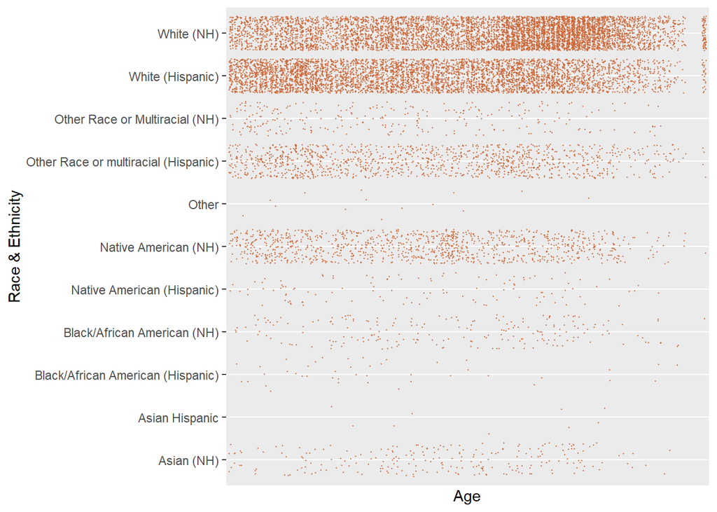

```r
ggplot(assignment3_vars, aes(x=race_ethnicity, y=AGEP)) +
  theme(axis.text.x = element_text(angle = 90)) +
  geom_point(position ="jitter", alpha =.75, color="sienna3", size=.25) +
  scale_x_discrete( name= "Race & Ethnicity") +
  scale_y_discrete( name ="Age") +
  coord_flip()
```

## **5. Decade Home Constructed**

### 5.1 Decade Home Constructed & Household Income

See 1.4

### 5.2 Decade Home Constructed & Numper of People

See 2.4

### 5.3 Decade Home Constructed & Commute to Work

See 3.4

### 5.4 Decade Home Constructed & Age of Person

See 4.4

### 5.5 Decade Home Constructed & Race and Ethnicity

**Type of Test** Two Categorical Variables –> CHi Squared Test –> Significance of Relationship (Though it will be wonky due to low numbers in Race&Ethnicity Categories)

```r
chi_sq_race_development <- chisq.test(assignment3_vars$development, assignment3_vars$race_ethnicity)
chi_sq_race_development
```

```
##
##  Pearson's Chi-squared test
##
## data:  assignment3_vars$development and assignment3_vars$race_ethnicity
## X-squared = 313.91, df = 80, p-value < 2.2e-16
```

```r
#Observed
chi_sq_race_development$observed
```

```
##
## assignment3_vars$development Asian (NH) Asian Hispanic
##                   1 pre 1940          5              0
##                   1940s              11              1
##                   1950s              14              2
##                   1960s              17              0
##                   1970s              52              0
##                   1980s              22              2
##                   1990s              48              1
##                   2000s              58              3
##                   2010s              10              0
##
## assignment3_vars$development Black/African American (Hispanic)
##                   1 pre 1940                                 3
##                   1940s                                      5
##                   1950s                                      4
##                   1960s                                      3
##                   1970s                                      8
##                   1980s                                      5
##                   1990s                                      5
##                   2000s                                      9
##                   2010s                                      1
##
## assignment3_vars$development Black/African American (NH)
##                   1 pre 1940                           7
##                   1940s                                6
##                   1950s                               19
##                   1960s                               29
##                   1970s                               25
##                   1980s                               36
##                   1990s                               30
##                   2000s                               43
##                   2010s                               17
##
## assignment3_vars$development Native American (Hispanic) Native American (NH)
##                   1 pre 1940                          3                   33
##                   1940s                               6                   27
##                   1950s                               2                   64
##                   1960s                              14                  140
##                   1970s                              20                  287
```

[output cut: 22 more lines]

```
##                   1980s                                  51              942
##                   1990s                                  49              977
##                   2000s                                  47              817
##                   2010s                                  14              284
##
## assignment3_vars$development White (NH)
##                   1 pre 1940        346
##                   1940s             217
##                   1950s             621
##                   1960s             657
##                   1970s            1137
##                   1980s            1133
##                   1990s            1173
##                   2000s            1092
##                   2010s             318
```

```r
#Expected
chi_sq_race_development$expected
```

```
##
## assignment3_vars$development Asian (NH) Asian Hispanic
##                   1 pre 1940  10.571495      0.4014492
##                   1940s        8.224024      0.3123047
##                   1950s       21.032706      0.7987104
##                   1960s       22.592435      0.8579406
##                   1970s       40.143322      1.5244300
##                   1980s       42.207206      1.6028053
##                   1990s       43.152496      1.6387024
##                   2000s       37.559529      1.4263112
##                   2010s       11.516785      0.4373463
##
## assignment3_vars$development Black/African American (Hispanic)
##                   1 pre 1940                          1.918035
##                   1940s                               1.492123
##                   1950s                               3.816061
##                   1960s                               4.099049
##                   1970s                               7.283388
##                   1980s                               7.657848
##                   1990s                               7.829356
##                   2000s                               6.814598
##                   2010s                               2.089543
##
## assignment3_vars$development Black/African American (NH)
##                   1 pre 1940                    9.456358
##                   1940s                         7.356511
##                   1950s                        18.814066
##                   1960s                        20.209267
##                   1970s                        35.908795
##                   1980s                        37.754969
##                   1990s                        38.600545
##                   2000s                        33.597554
##                   2010s                        10.301934
##
## assignment3_vars$development Native American (Hispanic) Native American (NH)
##                   1 pre 1940                   5.129628             50.13654
##                   1940s                        3.990560             39.00339
##                   1950s                       10.205744             99.75005
##                   1960s                       10.962574            107.14724
##                   1970s                       19.478827            190.38436
```

[output cut: 22 more lines]

```
##                   1980s                           48.440338         906.6535
##                   1990s                           49.525228         926.9593
##                   2000s                           43.106295         806.8167
##                   2010s                           13.217576         247.3922
##
## assignment3_vars$development White (NH)
##                   1 pre 1940   298.5890
##                   1940s        232.2853
##                   1950s        594.0630
##                   1960s        638.1171
##                   1970s       1133.8371
##                   1980s       1192.1310
##                   1990s       1218.8304
##                   2000s       1060.8586
##                   2010s        325.2884
```

**Analysis of Test**: The Chi-Squared Test indicated that there is a significant relationship between Race & Ethnicity and Decade Home Was Built.

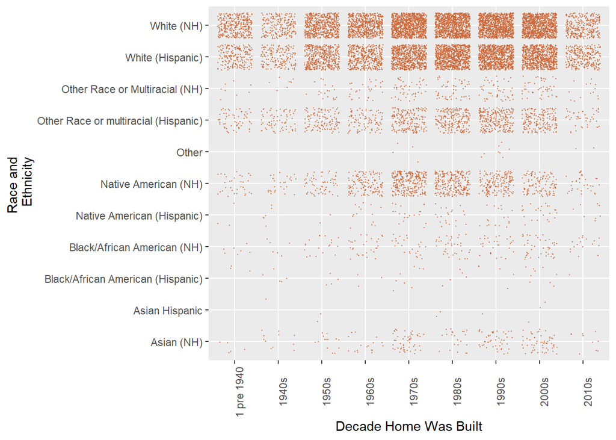

```r
ggplot(assignment3_vars, aes(x=development, y=race_ethnicity)) +
  theme(axis.text.x = element_text(angle = 90)) +
  geom_point(position ="jitter", alpha =.75, color="sienna3", size=.25) +
  scale_x_discrete( name= "Decade Home Was Built") +
  scale_y_discrete( name ="Race and \n Ethnicity")
```

## **6 Race and Ethnicity**

### 6.1 Race and Ethnicity & Household Income

See 1.5

### 6.2 Race and Ethnicity & Number of People in House

See 2.5

### 6.3 Race and Ethnicity & COmmute to Work

See 3.5

### 6.4 Race and Ethnicity & Age of Person

See 4.5

### 6.5 Race and Ethnicity & Year House Constructed

See 5.5

## **R Cheat Sheet, References & Troubleshooting**

Hello! I see this area of my assignment as predominantly a resource for myself as I learn R and as a resource to R if I ever need to return after a hiatus (and have forgotten everything I know).

Feel free to look through, but there is no need to grade anything in this section.

R Collaborative Flowchart: https://miro.com/app/board/o9J_klc5-mA=/

** Sage’s Troubleshooting Checklist**  
0. Breathe.  
1. Is everything spelled/cApiTAlized correctly?  
2. Count your parentheses(), commas, and “quotes”  
2.1 Check poles %>%, |  
3. Have you run the R chunks that are before the chunk with your error.  
5. What is the last thing you changed? Did you make sure you changed it in ALL the places it needs to be changed?  
6. Breathe. Maybe get a glass of water.  
7. Type in the ?function() into the Console  
8. Do a Google search for “R Markdown” + Your Problem  
9. Try retyping the function from scratch. 10. Try copying and pasting sections in another R Chunk –> Isolate the Problem  
11. Phone a friend.

**Common Errors:**  
-If you are having a function not found error, check whether or not you have run your libraries.  
-YAML error, check the very beginning of your code -

**If you want to see the values of a variable as they appear in your dataset** #Race  
#unique(household_data$RAC1P_label) <br/> #Hispanic <br/> #unique(household_data$HISP_label)

### References

**For General R** R is for Data Science https://r4ds.had.co.nz/index.html

Data Wrangling Cheat Sheet https://rstudio.com/wp-content/uploads/2015/02/data-wrangling-cheatsheet.pdf

*formatting* https://rstudio.com/wp-content/uploads/2015/02/rmarkdown-cheatsheet.pdf

*For GGPLOT** Top 50 Graph Types http://r-statistics.co/Top50-Ggplot2-Visualizations-MasterList-R-Code.html#Violin%20Plot

GGplot Cheat Sheet https://rstudio.com/wp-content/uploads/2015/03/ggplot2-cheatsheet.pdf

Color Pallets https://www.datanovia.com/en/blog/ggplot-colors-best-tricks-you-will-love/#predefined-ggplot-color-palettes

Look into Wes Anderson Themes, WSJ, Economist

**Number Crunching**

Another Way of Pulling Summary  
#mean(household_data$HINCP) <br/> #quantile(household_data$HINCP)  
#sd(household_data$HINCP)

Simple Explanation of Dsitributions: https://nezumisa.wordpress.com/2013/06/03/different-types-of-distributions/